# PD7

Piotr Pasza Storozenko

23 05 2019

# PD7 – Titanic chatbot

## What does bot didn’t understand / what functions should be added IMHO?

Sometimes I didn’t know if bot didn’t understand me or what so I’ll paste here some weird interactions.

In the begining of the conversation:

Me: Hi

Bot: Hi

Hello! I’m DrAnt, a Titanic survival bot. Let’s see whether you would’ve survived on Titanic and discuss the model predictions.

Bot: You might start by telling some details about you

Bot: List variables and ask about their meaning at any time

Bot: You might also start as Jack or Rose from the movie

Me: Let’s start from the movie!

Bot: Let’s start from the beginning!

???

Me: gender

Bot: Gender either “male” or “female”

Me: thanks

Bot: Thanks for being nice ;) But this won’t help you to survive on Titanic!

Me: What could help me then?

Bot: list all variablesdescribe the problemwhat do you know about

???

Bot: I’m sorry. It looks like you would’ve died on Titanic. Your chance of survival equals 0.2343

Me: That’s bad, don’t you think?

Bot: Sorry, I don’t understand yet. But I’ll learn from this conversation and improve in the future!

Bot: Click below if you need help

???

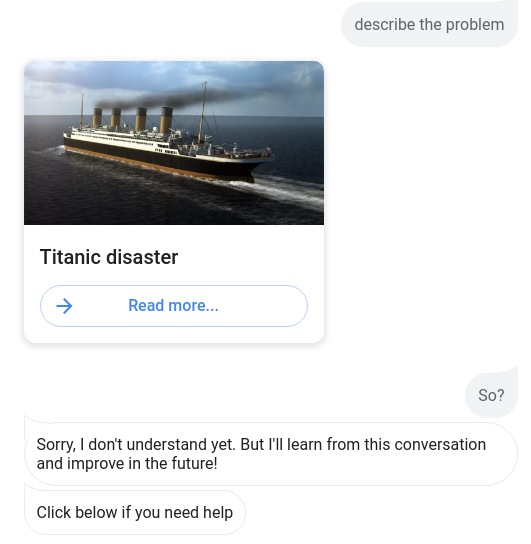

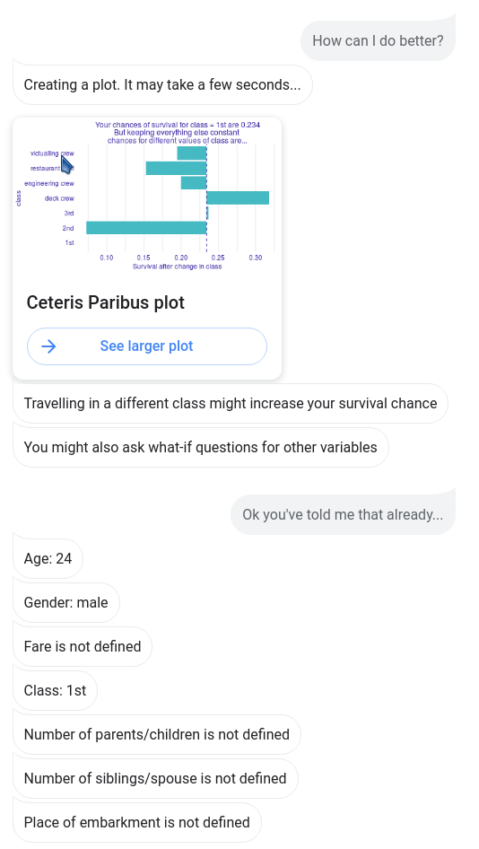

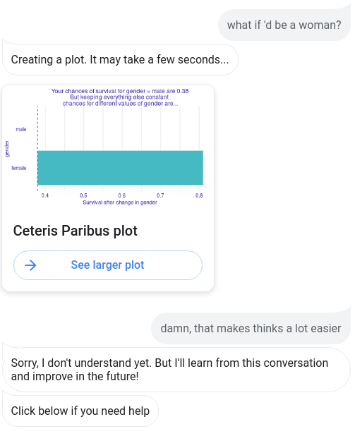

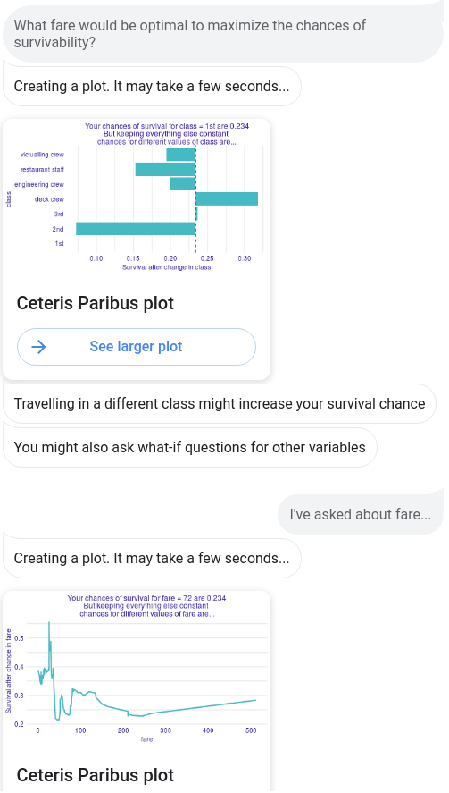

Me: Tell me a joke!

Bot: Sorry, I don’t understand yet. But I’ll learn from this conversation and improve in the future!

Click below if you need help

:(

Me: Who would die for sure?

Bot: You haven’t specified the value for any variable - your chance of survival is an average chance across passengers [empty breakdown plot]

Me: I’m 24, man, I’m rich and travel in first class but it doesn’t matter.

Bot: I’m sorry. It looks like you would’ve died on Titanic. Your chance of survival equals 0.2343

Me: So who would die for sure?

Bot: [Breakdown plot for me]

## Conclusion

Bot mostly understood me, that’s great.

I’d be pleased if this bot had options to present me optimal values for maximizing/minimizing survivability probability.